hgraph module - simul module - paper figures

# Example simulations for the hanna package using the simul module

Detlef Groth, University of Potsdam, Germany

2023-02-13

## Introduction

The hanna package contains two modules, environments for doing winner looser simulations and evaluating the resulting network structure.

The simul environment provides the following methods:

- *simul$pairings* - create round pairings for a single season
- *simul$season* - create matches for everyone against everyone using the given model and evaluate the results
- *simul$graph* - create a adjacency matrix out of the results for a match season
- *simul$compare* - compare the different models for a certain number of seasons, does a lot of iterations to compare the models several times

## Pairings

This just allows to create matches where in every round the agents get a new partner, here an example for a small group of 6 agents giving all together 15 matches:

```r
library(hanna)
set.seed(123)
simul$pairings(LETTERS[1:6])
```

```
##    round A B
## 1      1 A F
## 2      1 B E
## 3      1 C D
## 4      2 A E
## 5      2 F D
## 6      2 B C
## 7      3 A D
## 8      3 E C
## 9      3 F B
## 10     4 A C
## 11     4 D B
## 12     4 E F
## 13     5 A B
## 14     5 C F
## 15     5 D E
```

The function is just needed internally in the `simul$season` function.

## Seasons

This module is used to perform a season where every agent is matched against other agents a single time and the winners earns token from the looser. Let’s do a single season using the null model where the outcome of a match does not depend on the amount of token the agents lost or gained during the competitions.

```r
res=simul$season(LETTERS[1:8])
res$token
```

```
##  A  B  C  D  E  F  G  H
##  6  9 10 10  6  8  8  7
```

```r
res$M
```

```
##    A  B  C  D E F G  H
## A  0 -1 -1  1 0 0 0 -1
## B  1  0 -1  0 0 0 0  1
## C  1  1  0 -1 0 0 0  1
## D -1  0  1  0 1 0 0  1
## E  0  0  0 -1 0 0 0 -1
## F  0  0  0  0 0 0 0  0
## G  0  0  0  0 0 0 0  0
## H  1 -1 -1 -1 1 0 0  0
```

A -1 in the matrix means a loss, a 1 a win, where you must read rowwise. So for instance A was loosing agains B in this season. The number of tokens is directly related to the number of wins and losses after a single season. We can use the token to create a new season with non-equal starting conditions.

```r
res2=simul$season(LETTERS[1:8],token=res$token)
res2$token
```

```
##  A  B  C  D  E  F  G  H
##  7  9 10  7  8 10  9  4
```

```r
res2$M
```

```
##    A B  C D  E  F  G H
## A  0 0  0 1  0 -1  1 0
## B  0 0  0 0  0  0  0 0
## C  0 0  0 0 -1  0  0 1
## D -1 0  0 0 -1  0 -1 0
## E  0 0  1 1  0 -1  1 0
## F  1 0  0 0  1  0 -1 1
## G -1 0  0 1 -1  1  0 1
## H  0 0 -1 0  0 -1 -1 0
```

Using the null model there should be no big changes after the iterations as the chance to win or loose is not dependent on the current amount of tokens. Let’s do a loop over ten seasons, each time sending the current number of tokens into the next iteration and let us compare this with the gain modelm the winner-looser model where the chance to win or loose is dependend on the current number of token:

```r
for (i in 1:10) {
   res2=simul$season(LETTERS[1:8],token=res2$token,mode="null")
}
res2$token
```

```
##  A  B  C  D  E  F  G  H
##  1 11 14  5  8 13 12  0
```

```r
res.gain=simul$season(LETTERS[1:8],model="gain")
for (i in 1:10) {
   res.gain=simul$season(LETTERS[1:8],token=res.gain$token,model="gain")
}
res.gain$token
```

```
##  A  B  C  D  E  F  G  H
##  0  0 20  0 14  0 24  6
```

As you can see the amount of token in the gain model is less balanced than that in the null mode. Let’s plot the resulting graphs side by side. For this we use the hgraph module which offers a view utility functions to work with graphs:

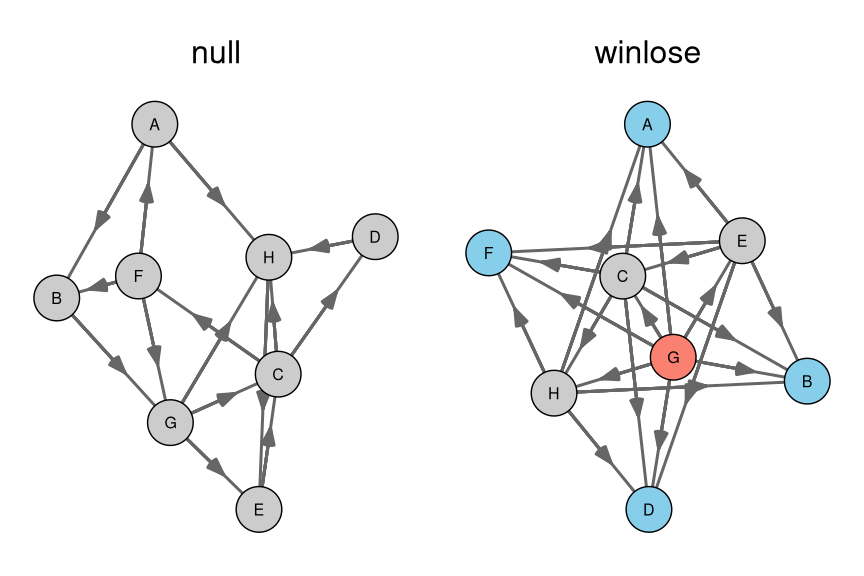

```r
par(mfrow=c(1,2),mai=c(0.1,0.1,0.7,0.1))
# make adjacency matrix out of win/loss matrix
A.null=simul$graph(res2$M,mode="win")
A.gain=simul$graph(res.gain$M,mode="win")
cols=hgraph$colors(A.null)
hgraph$plot(A.null,vertex.color=cols)
mtext(side=3,"null",cex=2)
cols=hgraph$colors(A.gain)
hgraph$plot(A.gain,vertex.color=cols)
mtext(side=3,"winlose",cex=2)
```

In red color are agents which does not loose any gaim, in blue are agents which does not win any game, in grey are agents displayed which win or lost at least one game each. As in the null model the chances to win and loose are not dependend on the token, you can see in the left figure that no team does not only win and draw or does only loose and draw wheres the agent G in the winner/looser model does not loose any game.

As comparison let’s run the model where the agents remember the last five results and loosing often diminishs the current chance and wining often increases the chance.

```r
res=simul$season(LETTERS[1:6],model="memory",memory.length=5)
res
```

```
## $M
##   A  B  C D  E F
## A 0 -1 -1 0  0 0
## B 1  0  1 1  0 1
## C 1 -1  0 0  0 0
## D 0 -1  0 0 -1 0
## E 0  0  0 1  0 1
## F 0 -1  0 0 -1 0
##
## $token
##  A  B  C  D  E  F
##  4 10  6  4  8  4
##
## $model
## [1] "memory"
##
## $memory
## $memory$A
## [1] -1 -1  0  0  0
##
## $memory$B
## [1] 1 1 1 1 0
##
## $memory$C
## [1]  0  1  0 -1  0
##
## $memory$D
## [1] -1 -1  0  0  0
##
## $memory$E
## [1] 1 1 0 0 0
##
## $memory$F
## [1]  0 -1 -1  0  0
```

## Triads

The `hgraph` object contains as well a method to count the triads in the graph:

```r
unlist(hgraph$triads(A.null))
```

```
## dd ds pa tr cy
##  4  4 14  6  2
```

```r
unlist(hgraph$triads(A.gain))
```

```
## dd ds pa tr cy
## 25  4  1 22  0
```

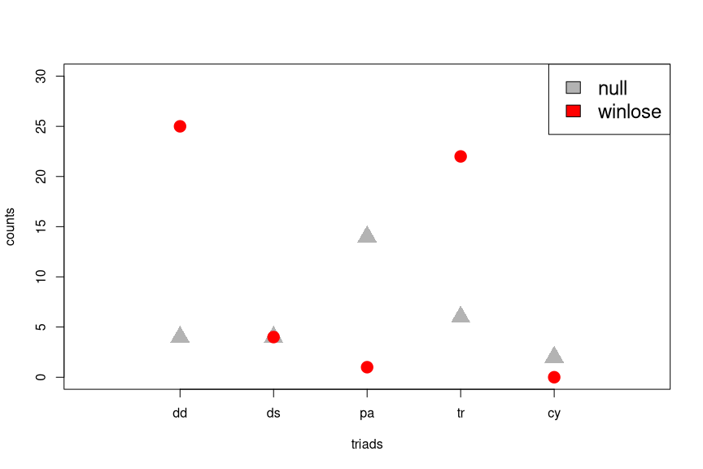

```r
plot(1,type="n",xlim=c(0,6),ylim=c(0,30),axes=FALSE,xlab="triads",ylab="counts")
points(x=c(1:5),y=unlist(hgraph$triads(A.null)),pch=17,col='grey70',cex=2.5)
points(x=c(1:5),y=unlist(hgraph$triads(A.gain)),pch=19,col='red',cex=2)
axis(1,at=1:5,labels=names(hgraph$triads(A.null)))
axis(2)
legend('topright',c("null","winlose"),fill=c('grey70','red'),cex=1.5)
box()
```